# DATA621 - Moneyball

Daniel Hong, Mauricio Alarcon, Maxwell Wagner

September 11, 2016

# NOTES

## Missing Data:

- TEAM_BATTING_SO, TEAM_BASERUN_SB, TEAM_PITCHING_SO and TEAM_FIELDING_DP are 90% or so complete, can we fill missing values with mean/median
- TEAM_BASERUN_CS, TEAM_BATTING_HBP are on the very incomplete side (66%, 8% respectively). Perhaps we can conver to Percent of Games Caught Stealing?, etc?
- I know nothing about baseball, can we tell the Number of Games Played?

## Correlations

The collosal scatterplot https://github.com/rmalarc/DATA621/blob/master/hw01/Rplot01.png shows some correlations, particularly TEAM_BATTING_H + TEAM_BATTING_2B, TEAM_BATTING_3B ~ target. Any ideas?

## 1. DATA EXPLORATION (25 Points)

Describe the size and the variables in the moneyball training data set. Consider that too much detail will cause a manager to lose interest while too little detail will make the manager consider that you aren’t doing your job. Some suggestions are given below. Please do NOT treat this as a check list of things to do to complete the assignment. You should have your own thoughts on what to tell the boss. These are just ideas.

1. Mean / Standard Deviation / Median

```r
require("plyr")
require("knitr")
require("psych")
# Let's load the data

training <- read.csv(url('https://raw.githubusercontent.com/rmalarc/DATA621/master/hw01/moneyball-training-data.csv'))
metadata <- read.csv(url('https://raw.githubusercontent.com/rmalarc/DATA621/master/hw01/moneyball-metadata.csv'))
evaluation <- read.csv(url('https://raw.githubusercontent.com/rmalarc/DATA621/master/hw01/moneyball-evaluation-data.csv'))

kable(metadata)
```

| Variable | Definiton | Theoretical.Effect |
| --- | --- | --- |
| INDEX | Identification Variable (do not use) | None |
| TARGET_WINS | Number of wins |  |
| TEAM_BATTING_H | Base Hits by batters (1B,2B,3B,HR) | Positive Impact on Wins |
| TEAM_BATTING_2B | Doubles by batters (2B) | Positive Impact on Wins |
| TEAM_BATTING_3B | Triples by batters (3B) | Positive Impact on Wins |
| TEAM_BATTING_HR | Homeruns by batters (4B) | Positive Impact on Wins |
| TEAM_BATTING_BB | Walks by batters | Positive Impact on Wins |
| TEAM_BATTING_HBP | Batters hit by pitch (get a free base) | Positive Impact on Wins |
| TEAM_BATTING_SO | Strikeouts by batters | Negative Impact on Wins |
| TEAM_BASERUN_SB | Stolen bases | Positive Impact on Wins |
| TEAM_BASERUN_CS | Caught stealing | Negative Impact on Wins |
| TEAM_FIELDING_E | Errors Negative | Impact on Wins |
| TEAM_FIELDING_DP | Double Plays | Positive Impact on Wins |
| TEAM_PITCHING_BB | Walks allowed | Negative Impact on Wins |
| TEAM_PITCHING_H | Hits allowed | Negative Impact on Wins |
| TEAM_PITCHING_HR | Homeruns allowed Negative | Impact on Wins |
| TEAM_PITCHING_SO | Strikeouts by pitchers | Positive Impact On Wins |

```r
columns <- colnames(training)
target <- "TARGET_WINS"
inputs <- columns[!columns %in% c(target,"INDEX")]

summary <- describe(training[,c(target,inputs)])[,c("n","mean","sd","median","max","min")]
summary$completeness <- summary$n/nrow(training)
kable(summary)
```

|  | n | mean | sd | median | max | min | completeness |
| --- | --- | --- | --- | --- | --- | --- | --- |
| TARGET_WINS | 2276 | 80.79086 | 15.75215 | 82.0 | 146 | 0 | 1.0000000 |
| TEAM_BATTING_H | 2276 | 1469.26977 | 144.59120 | 1454.0 | 2554 | 891 | 1.0000000 |
| TEAM_BATTING_2B | 2276 | 241.24692 | 46.80141 | 238.0 | 458 | 69 | 1.0000000 |
| TEAM_BATTING_3B | 2276 | 55.25000 | 27.93856 | 47.0 | 223 | 0 | 1.0000000 |
| TEAM_BATTING_HR | 2276 | 99.61204 | 60.54687 | 102.0 | 264 | 0 | 1.0000000 |
| TEAM_BATTING_BB | 2276 | 501.55888 | 122.67086 | 512.0 | 878 | 0 | 1.0000000 |
| TEAM_BATTING_SO | 2174 | 735.60534 | 248.52642 | 750.0 | 1399 | 0 | 0.9551845 |
| TEAM_BASERUN_SB | 2145 | 124.76177 | 87.79117 | 101.0 | 697 | 0 | 0.9424429 |
| TEAM_BASERUN_CS | 1504 | 52.80386 | 22.95634 | 49.0 | 201 | 0 | 0.6608084 |
| TEAM_BATTING_HBP | 191 | 59.35602 | 12.96712 | 58.0 | 95 | 29 | 0.0839192 |
| TEAM_PITCHING_H | 2276 | 1779.21046 | 1406.84293 | 1518.0 | 30132 | 1137 | 1.0000000 |
| TEAM_PITCHING_HR | 2276 | 105.69859 | 61.29875 | 107.0 | 343 | 0 | 1.0000000 |
| TEAM_PITCHING_BB | 2276 | 553.00791 | 166.35736 | 536.5 | 3645 | 0 | 1.0000000 |
| TEAM_PITCHING_SO | 2174 | 817.73045 | 553.08503 | 813.5 | 19278 | 0 | 0.9551845 |
| TEAM_FIELDING_E | 2276 | 246.48067 | 227.77097 | 159.0 | 1898 | 65 | 1.0000000 |
| TEAM_FIELDING_DP | 1990 | 146.38794 | 26.22639 | 149.0 | 228 | 52 | 0.8743409 |

2. Bar Chart or Box Plot of the data

### How are the input values distributed?, do we need to do something about them?

Here’s the distribution of the values for each of the variables

```r
require("reshape2")
```

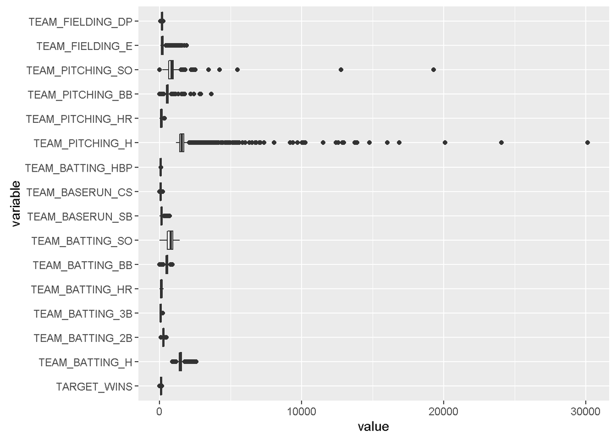

```r
require("ggplot2")
# Let's melt the DF so that we can plot it more easily

ggplot(melt(training, measure.vars = c(target,inputs))
       ,aes(x=variable,y=value)
       )+
    geom_boxplot() +
    coord_flip()
```

Some of these probably need to be rescaled: TEAM_PITCHING_H, TEAM_PITCHING_SO (what is this????)

Let’s get a view of the normalized values:

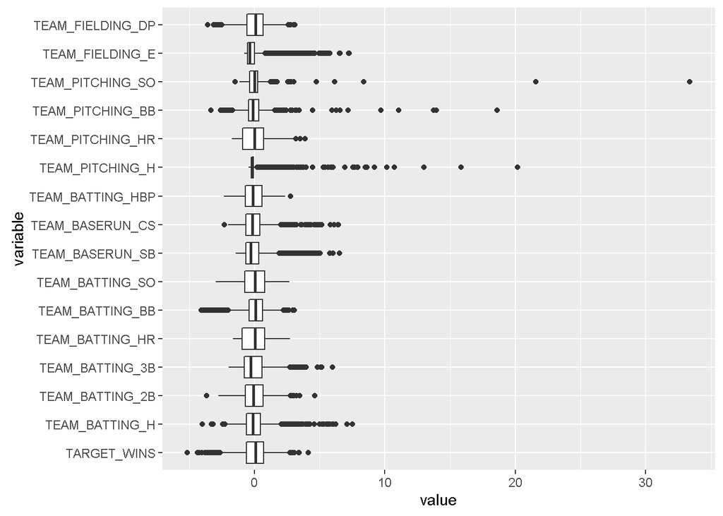

```r
require("reshape2")
require("ggplot2")
# Let's melt the DF so that we can plot it more easily

ggplot(melt(data.frame(scale(training)), measure.vars = c(target,inputs)),
       aes(x=variable,y=value)
       )+
    geom_boxplot() +
    coord_flip()
```

the case for data transformations is a lot more self-evident now!

Let’s see what it looks like with a log transformation:

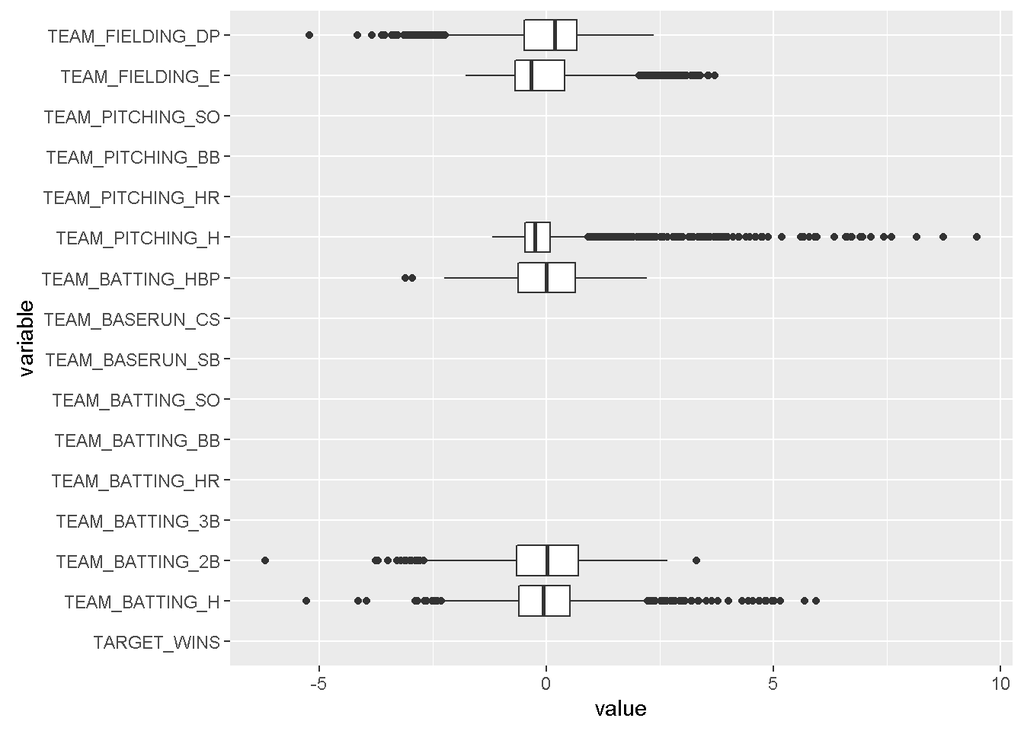

```r
ggplot(melt(data.frame(scale(log(training))), measure.vars = c(target,inputs)),
       aes(x=variable,y=value)
       )+
    geom_boxplot() +
    coord_flip()
```

3. Is the data correlated to the target variable (or to other variables?)

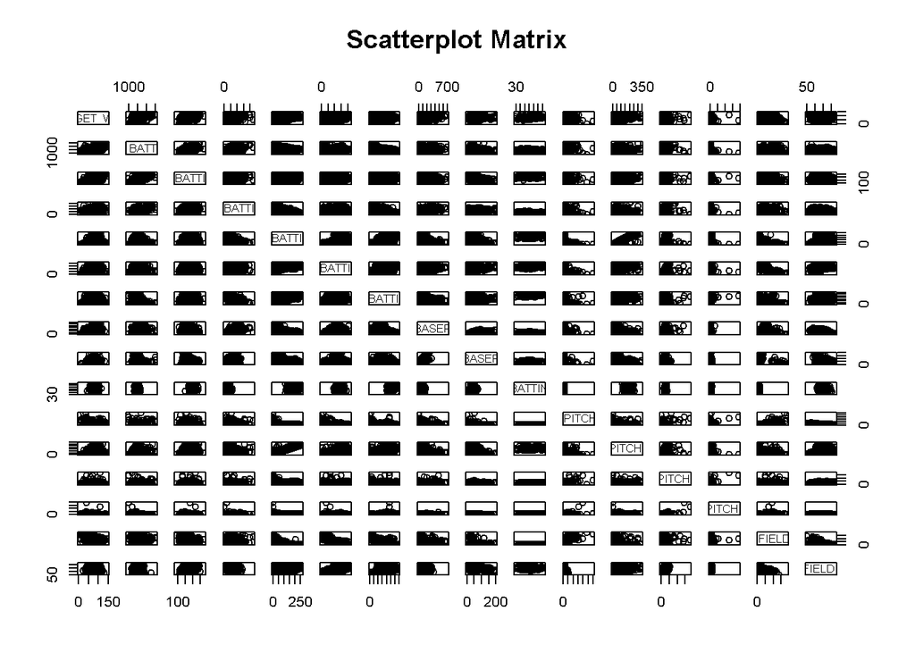

```r
pairs(~.,data=training[,c(target,inputs)],
   main="Scatterplot Matrix")
```

```r
# LEt's see the correlation matrix

kable(cor(training[,c(target,inputs)], use="pairwise.complete.obs", method="kendall") )
```

|  | TARGET_WINS | TEAM_BATTING_H | TEAM_BATTING_2B | TEAM_BATTING_3B | TEAM_BATTING_HR | TEAM_BATTING_BB | TEAM_BATTING_SO | TEAM_BASERUN_SB | TEAM_BASERUN_CS | TEAM_BATTING_HBP | TEAM_PITCHING_H | TEAM_PITCHING_HR | TEAM_PITCHING_BB | TEAM_PITCHING_SO | TEAM_FIELDING_E | TEAM_FIELDING_DP |
| --- | --- | --- | --- | --- | --- | --- | --- | --- | --- | --- | --- | --- | --- | --- | --- | --- |
| TARGET_WINS | 1.0000000 | 0.2578130 | 0.1624482 | 0.0811299 | 0.1102447 | 0.1661288 | -0.0515269 | 0.0775086 | -0.0052072 | 0.0195018 | 0.1514105 | 0.1155198 | 0.1505342 | -0.0633447 | -0.0884986 | -0.0352128 |
| TEAM_BATTING_H | 0.2578130 | 1.0000000 | 0.4277854 | 0.2253093 | 0.0524225 | 0.0543397 | -0.2734543 | 0.0008908 | 0.0133934 | -0.0199818 | 0.6341824 | 0.0783882 | 0.1068980 | -0.2548211 | 0.0671167 | 0.1231197 |
| TEAM_BATTING_2B | 0.1624482 | 0.4277854 | 1.0000000 | -0.1055129 | 0.3115901 | 0.1853419 | 0.1136354 | -0.1088553 | -0.0163502 | 0.0118159 | 0.2006267 | 0.3195367 | 0.1483852 | 0.0741572 | -0.2621964 | 0.1708179 |
| TEAM_BATTING_3B | 0.0811299 | 0.2253093 | -0.1055129 | 1.0000000 | -0.4737686 | -0.1957625 | -0.5198592 | 0.2383025 | 0.1344331 | -0.1215264 | 0.3820188 | -0.4472653 | -0.0692720 | -0.4282504 | 0.5376888 | -0.1651927 |
| TEAM_BATTING_HR | 0.1102447 | 0.0524225 | 0.3115901 | -0.4737686 | 1.0000000 | 0.3467213 | 0.5251584 | -0.2723937 | -0.2595813 | 0.0545571 | -0.1971559 | 0.9289328 | 0.1964719 | 0.4091055 | -0.6029884 | 0.2629838 |
| TEAM_BATTING_BB | 0.1661288 | 0.0543397 | 0.1853419 | -0.1957625 | 0.3467213 | 1.0000000 | 0.1790785 | -0.1024013 | -0.1137001 | 0.0059697 | -0.0938700 | 0.3208197 | 0.7639836 | 0.0785126 | -0.3026772 | 0.2194524 |
| TEAM_BATTING_SO | -0.0515269 | -0.2734543 | 0.1136354 | -0.5198592 | 0.5251584 | 0.1790785 | 1.0000000 | -0.0740256 | -0.1167562 | 0.1202472 | -0.4303690 | 0.4921480 | 0.0411094 | 0.8257782 | -0.5318635 | 0.0593358 |
| TEAM_BASERUN_SB | 0.0775086 | 0.0008908 | -0.1088553 | 0.2383025 | -0.2723937 | -0.1024013 | -0.0740256 | 1.0000000 | 0.4898029 | -0.0209281 | 0.0907725 | -0.2625464 | -0.0129995 | -0.0373803 | 0.2401202 | -0.2895276 |
| TEAM_BASERUN_CS | -0.0052072 | 0.0133934 | -0.0163502 | 0.1344331 | -0.2595813 | -0.1137001 | -0.1167562 | 0.4898029 | 1.0000000 | -0.0435396 | 0.0101378 | -0.2534545 | -0.0853003 | -0.1070170 | 0.1437337 | -0.0939819 |
| TEAM_BATTING_HBP | 0.0195018 | -0.0199818 | 0.0118159 | -0.1215264 | 0.0545571 | 0.0059697 | 0.1202472 | -0.0209281 | -0.0435396 | 1.0000000 | -0.0159068 | 0.0552225 | 0.0066409 | 0.1211429 | 0.0493273 | -0.0485670 |
| TEAM_PITCHING_H | 0.1514105 | 0.6341824 | 0.2006267 | 0.3820188 | -0.1971559 | -0.0938700 | -0.4303690 | 0.0907725 | 0.0101378 | -0.0159068 | 1.0000000 | -0.1295899 | 0.1047002 | -0.2741411 | 0.3301306 | 0.0268468 |
| TEAM_PITCHING_HR | 0.1155198 | 0.0783882 | 0.3195367 | -0.4472653 | 0.9289328 | 0.3208197 | 0.4921480 | -0.2625464 | -0.2534545 | 0.0552225 | -0.1295899 | 1.0000000 | 0.2204894 | 0.4190538 | -0.5579081 | 0.2641637 |
| TEAM_PITCHING_BB | 0.1505342 | 0.1068980 | 0.1483852 | -0.0692720 | 0.1964719 | 0.7639836 | 0.0411094 | -0.0129995 | -0.0853003 | 0.0066409 | 0.1047002 | 0.2204894 | 1.0000000 | 0.0294722 | -0.1323484 | 0.1847743 |
| TEAM_PITCHING_SO | -0.0633447 | -0.2548211 | 0.0741572 | -0.4282504 | 0.4091055 | 0.0785126 | 0.8257782 | -0.0373803 | -0.1070170 | 0.1211429 | -0.2741411 | 0.4190538 | 0.0294722 | 1.0000000 | -0.4012185 | 0.0063776 |
| TEAM_FIELDING_E | -0.0884986 | 0.0671167 | -0.2621964 | 0.5376888 | -0.6029884 | -0.3026772 | -0.5318635 | 0.2401202 | 0.1437337 | 0.0493273 | 0.3301306 | -0.5579081 | -0.1323484 | -0.4012185 | 1.0000000 | -0.2502193 |
| TEAM_FIELDING_DP | -0.0352128 | 0.1231197 | 0.1708179 | -0.1651927 | 0.2629838 | 0.2194524 | 0.0593358 | -0.2895276 | -0.0939819 | -0.0485670 | 0.0268468 | 0.2641637 | 0.1847743 | 0.0063776 | -0.2502193 | 1.0000000 |

4. Are any of the variables missing and need to be imputed “fixed”?

## 2. DATA PREPARATION (25 Points)

Describe how you have transformed the data by changing the original variables or creating new variables. If you did transform the data or create new variables, discuss why you did this. Here are some possible transformations.

1. Fix missing values (maybe with a Mean or Median value)
2. Create flags to suggest if a variable was missing
3. Transform data by putting it into buckets
4. Mathematical transforms such as log or square root (or use Box-Cox)
5. Combine variables (such as ratios or adding or multiplying) to create new variables

```r
# and a refression on the raw data to see what comes out of it
complete_cols <- row.names( summary[summary$completeness == 1,])
complete_cols <- c(complete_cols[complete_cols!=target])

training_transformed <- training[,c(target,complete_cols)]


# make up for missing TEAM_BATTING_SO
training[is.na(training$TEAM_BATTING_SO),]$TEAM_BATTING_SO <- median(training$TEAM_BATTING_SO, na.rm = TRUE)
training_transformed$TEAM_BATTING_SO <- training$TEAM_BATTING_SO

# make up for missing TEAM_BASERUN_SB
training[is.na(training$TEAM_BASERUN_SB),]$TEAM_BASERUN_SB <- median(training$TEAM_BASERUN_SB, na.rm = TRUE)
training_transformed$TEAM_BASERUN_SB <- training$TEAM_BASERUN_SB

# make up for missing TEAM_PITCHING_SO
training[is.na(training$TEAM_PITCHING_SO),]$TEAM_PITCHING_SO <- median(training$TEAM_PITCHING_SO, na.rm = TRUE)
training_transformed$TEAM_PITCHING_SO <- training$TEAM_PITCHING_SO

# make up for missing TEAM_FIELDING_DP
training[is.na(training$TEAM_FIELDING_DP),]$TEAM_FIELDING_DP <- median(training$TEAM_FIELDING_DP, na.rm = TRUE)
training_transformed$TEAM_FIELDING_DP <- training$TEAM_FIELDING_DP

# make up for missing TEAM_BASERUN_CS
#training[is.na(training$TEAM_BASERUN_CS),]$TEAM_BASERUN_CS  <- median(training$TEAM_BASERUN_CS, na.rm = TRUE)
#training_transformed$TEAM_BASERUN_CS <- training$TEAM_BASERUN_CS


#training_transformed$TEAM_BATTING_1B <- (training_transformed$TEAM_BATTING_2B-training_transformed$TEAM_BATTING_3B+training_transformed$TEAM_BATTING_HR)

# validation algo
#training_transformed$INVALID <- FALSE
#training_transformed$INVALID <- training_transformed$INVALID | training_transformed$TEAM_BATTING_1B < 811 | training_transformed$TEAM_BATTING_1B>1338
#length(training_transformed$INVALID[training_transformed$INVALID])

training_transformed$INVALID <- FALSE
training_transformed$INVALID <- training_transformed$INVALID | training_transformed$TEAM_BATTING_2B < 110 | training_transformed$TEAM_BATTING_2B>376
length(training_transformed$INVALID[training_transformed$INVALID])
```

```
## [1] 8
```

```r
training_transformed$INVALID <- training_transformed$INVALID | training_transformed$TEAM_BATTING_3B < 11 | training_transformed$TEAM_BATTING_3B>153
length(training_transformed$INVALID[training_transformed$INVALID])
```

```
## [1] 20
```

```r
training_transformed$INVALID <- training_transformed$INVALID | training_transformed$TEAM_BATTING_HR < 3 | training_transformed$TEAM_BATTING_HR>264
length(training_transformed$INVALID[training_transformed$INVALID])
```

```
## [1] 31
```

```r
training_transformed$INVALID <- training_transformed$INVALID | training_transformed$TEAM_BATTING_H < 935 | training_transformed$TEAM_BATTING_H>2131
length(training_transformed$INVALID[training_transformed$INVALID])
```

```
## [1] 39
```

```r
training_transformed$INVALID <- training_transformed$INVALID | training_transformed$TEAM_BATTING_SO < 308 | training_transformed$TEAM_BATTING_SO>1535
length(training_transformed$INVALID[training_transformed$INVALID])
```

```
## [1] 74
```

```r
training_transformed$INVALID <- training_transformed$INVALID | training_transformed$TEAM_PITCHING_SO < 308 | training_transformed$TEAM_PITCHING_SO>1535
length(training_transformed$INVALID[training_transformed$INVALID])
```

```
## [1] 89
```

```r
training_transformed$INVALID <- training_transformed$INVALID | training_transformed$TEAM_BATTING_BB < 282 | training_transformed$TEAM_BATTING_BB>835
length(training_transformed$INVALID[training_transformed$INVALID])
```

```
## [1] 163
```

```r
training_transformed$INVALID <- training_transformed$INVALID | training_transformed$TEAM_PITCHING_BB < 282 | training_transformed$TEAM_PITCHING_BB>835
length(training_transformed$INVALID[training_transformed$INVALID])
```

```
## [1] 192
```

```r
#training_transformed$INVALID <- training_transformed$INVALID | training_transformed$TEAM_BASERUN_CS < 8 | training_transformed$TEAM_BASERUN_CS>191
#length(training_transformed$INVALID[training_transformed$INVALID])

training_transformed$INVALID <- training_transformed$INVALID | training_transformed$TEAM_BASERUN_SB < 13 | training_transformed$TEAM_BASERUN_SB>638
length(training_transformed$INVALID[training_transformed$INVALID])
```

```
## [1] 194
```

```r
#training_transformed <- training_transformed[!training_transformed$INVALID,]


#training_transformed$TEAM_BATTING_1B <- training_transformed$TEAM_BATTING_1B/training_transformed$TEAM_BATTING_H

#training_transformed$TEAM_BATTING_2B <- training_transformed$TEAM_BATTING_2B/training_transformed$TEAM_BATTING_H
#training_transformed$TEAM_BATTING_3B <- training_transformed$TEAM_BATTING_3B/training_transformed$TEAM_BATTING_H
#training_transformed$TEAM_BATTING_HR <- training_transformed$TEAM_BATTING_HR/training_transformed$TEAM_BATTING_H


#training_transformed$TEAM_PITCHING_HR <- training_transformed$TEAM_PITCHING_HR/training_transformed$TEAM_PITCHING_H


library(MASS)
valid_data <- training_transformed[!training_transformed$INVALID&complete.cases(training_transformed),colnames(training_transformed)[!colnames(training_transformed) %in% c("INVALID")]]
```

# Model 0: A Mean based model

Let’s try a straight up regression whatever linear regression

```r
model <- lm(TARGET_WINS~1,data=valid_data)
summary(model)
```

```
##
## Call:
## lm(formula = TARGET_WINS ~ 1, data = valid_data)
##
## Residuals:
##     Min      1Q  Median      3Q     Max
## -53.899  -8.899   1.101  10.101  45.101
##
## Coefficients:
##             Estimate Std. Error t value Pr(>|t|)
## (Intercept)  80.8987     0.3109   260.2   <2e-16 ***
## ---
## Signif. codes:  0 '***' 0.001 '**' 0.01 '*' 0.05 '.' 0.1 ' ' 1
##
## Residual standard error: 14.19 on 2081 degrees of freedom
```

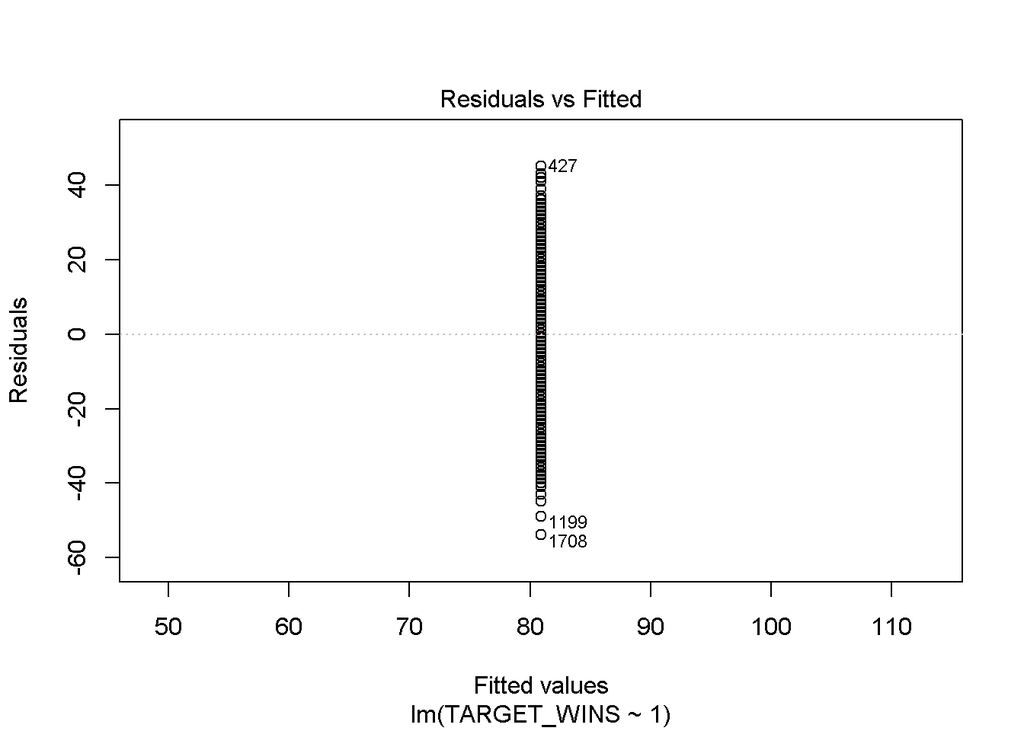

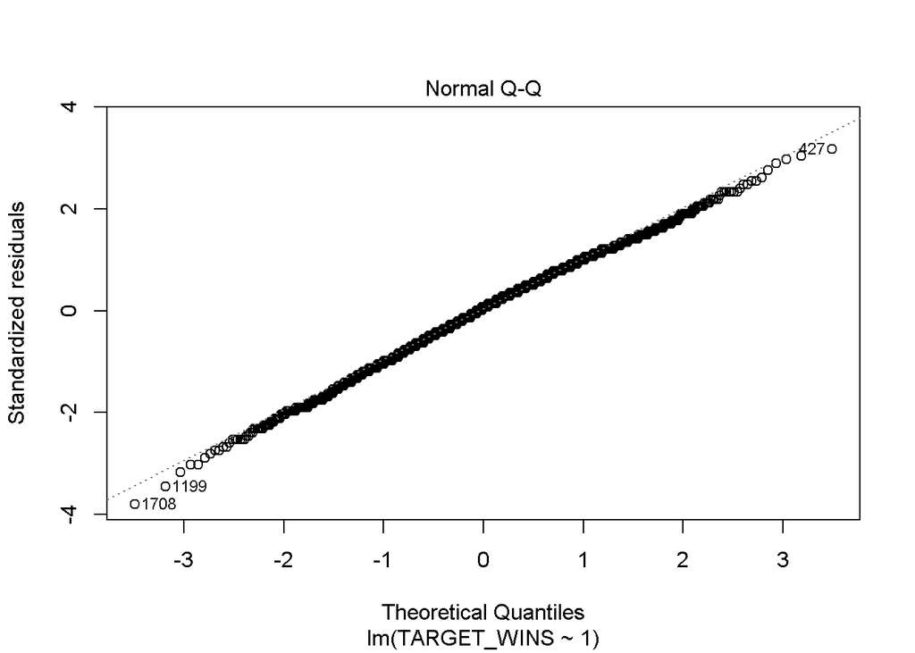

```
## hat values (leverages) are all = 0.0004803074
##  and there are no factor predictors; no plot no. 5
```

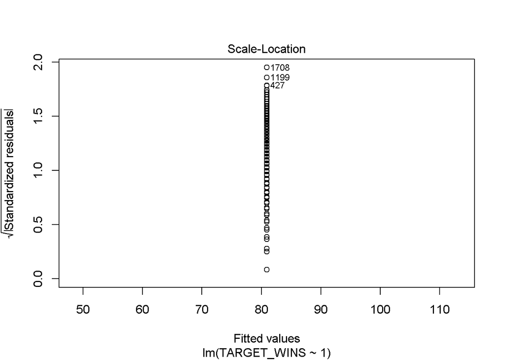

```r
model0 <- model
model0_y_power <- 1
plot(model)
```

# Model 1: A Straight Up Model

Let’s try a straight up regression whatever linear regression

```r
model <- lm(TARGET_WINS~.+0,data=valid_data)
summary(model)
```

```
##
## Call:
## lm(formula = TARGET_WINS ~ . + 0, data = valid_data)
##
## Residuals:
##     Min      1Q  Median      3Q     Max
## -44.023  -7.526   0.035   7.644  65.759
##
## Coefficients:
##                   Estimate Std. Error t value Pr(>|t|)
## TEAM_BATTING_H   -0.036425   0.010741  -3.391 0.000709 ***
## TEAM_BATTING_2B  -0.061255   0.008525  -7.185 9.32e-13 ***
## TEAM_BATTING_3B   0.159143   0.018703   8.509  < 2e-16 ***
## TEAM_BATTING_HR   0.456476   0.076259   5.986 2.53e-09 ***
## TEAM_BATTING_BB   0.388537   0.034731  11.187  < 2e-16 ***
## TEAM_PITCHING_H   0.085238   0.009865   8.640  < 2e-16 ***
## TEAM_PITCHING_HR -0.384458   0.072216  -5.324 1.13e-07 ***
## TEAM_PITCHING_BB -0.329688   0.032378 -10.183  < 2e-16 ***
## TEAM_FIELDING_E  -0.063789   0.004234 -15.068  < 2e-16 ***
## TEAM_BATTING_SO  -0.120387   0.016864  -7.139 1.30e-12 ***
## TEAM_BASERUN_SB   0.057361   0.004670  12.282  < 2e-16 ***
## TEAM_PITCHING_SO  0.113710   0.015607   7.286 4.53e-13 ***
## TEAM_FIELDING_DP -0.081378   0.011974  -6.796 1.40e-11 ***
## ---
## Signif. codes:  0 '***' 0.001 '**' 0.01 '*' 0.05 '.' 0.1 ' ' 1
##
## Residual standard error: 11.6 on 2069 degrees of freedom
## Multiple R-squared:  0.9802, Adjusted R-squared:  0.9801
## F-statistic:  7875 on 13 and 2069 DF,  p-value: < 2.2e-16
```

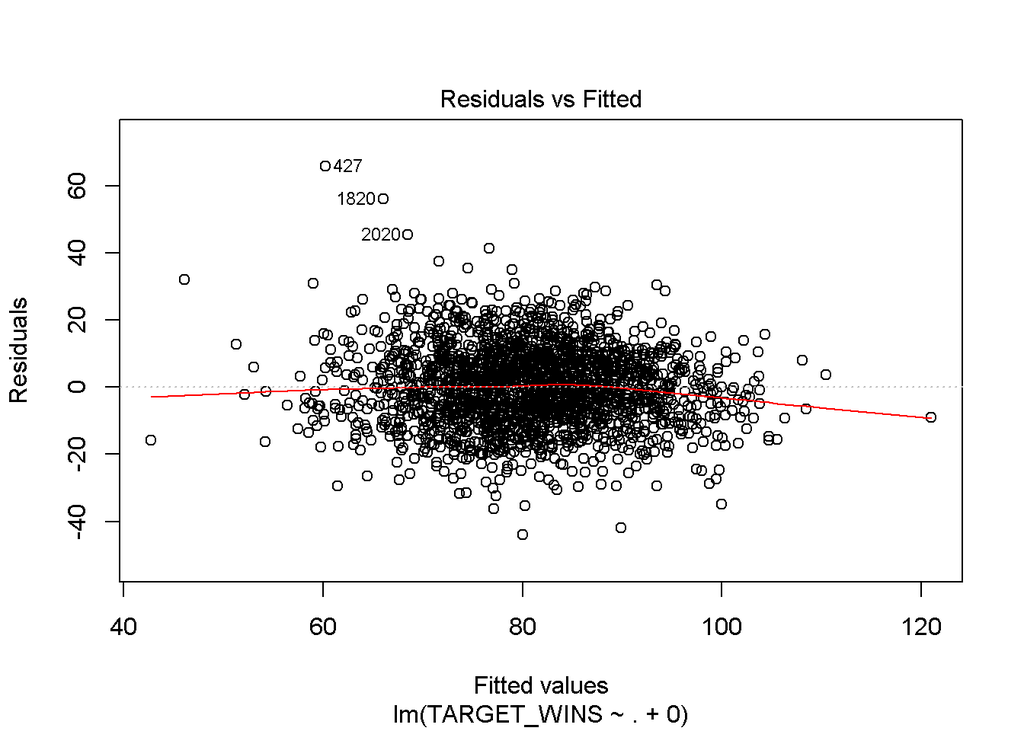

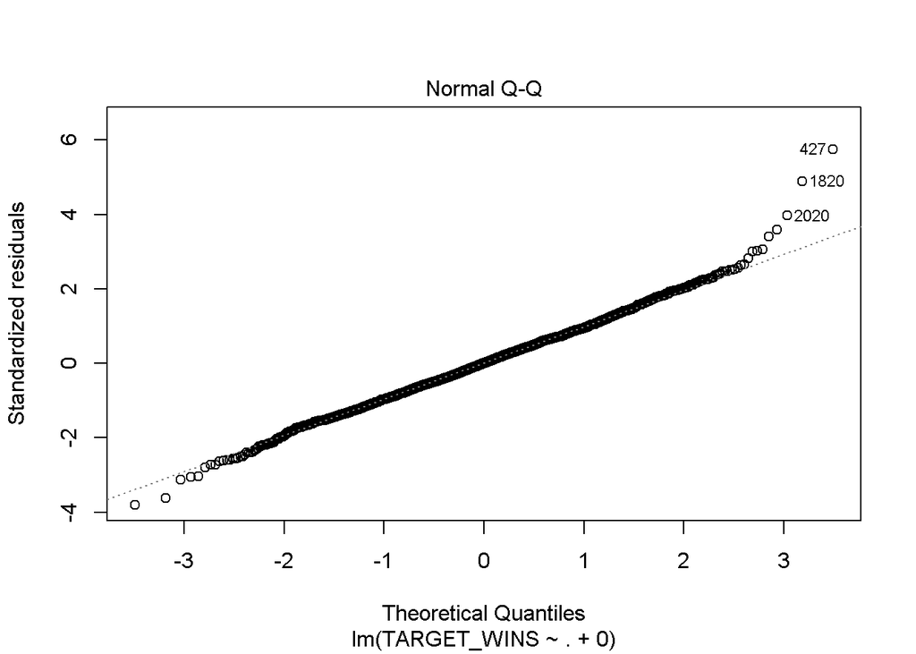

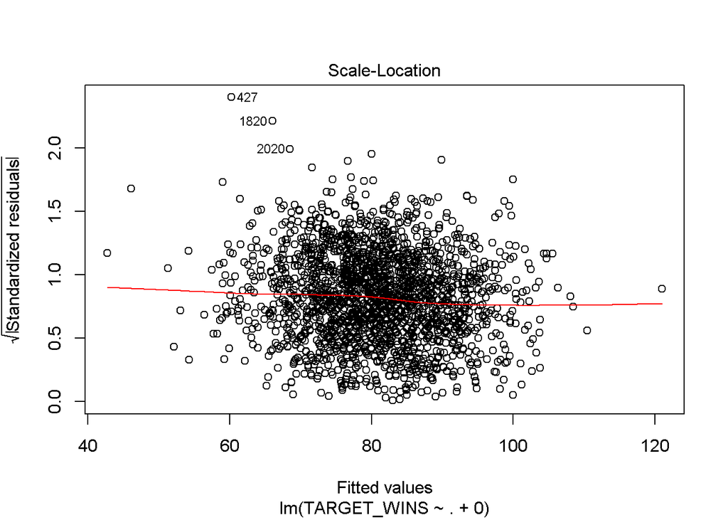

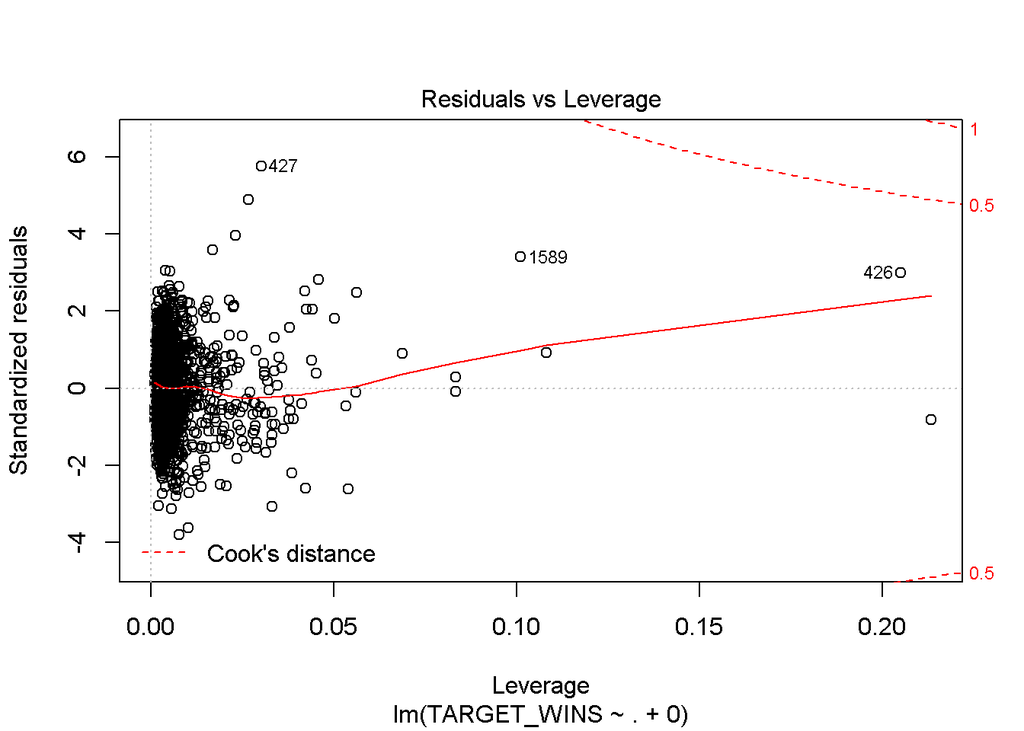

```r
model1 <- model
model1_y_power <- 1
model1_powers <- 1
plot(model)
```

# Model 2: A Power Model on Just Y

The residual curves look funky. Let’s apply some power transformations to the same model:

```r
getBoxCoxCoef<-function(x,y){
  if (min(x)<=0){1} else {
    d<-boxcox(x~y, plotit = FALSE)
    d <- data.frame(d)
    max_x <- d[d$y == max(d$y),]$x
    if (abs(max_x)<=(1/3)) 1 else max_x
  }
}

model_data <- valid_data

d<-boxcox(TARGET_WINS+0.0001~.,data=model_data, plotit = FALSE)

d <- data.frame(d)

y_power <- d[d$y == max(d$y),]$x
y_power
```

```
## [1] 1.2
```

```r
model_data$TARGET_WINS <- with(model_data,TARGET_WINS^y_power)
model <- lm(TARGET_WINS~.+0,data=model_data)
summary(model)
```

```
##
## Call:
## lm(formula = TARGET_WINS ~ . + 0, data = model_data)
##
## Residuals:
##      Min       1Q   Median       3Q      Max
## -119.200  -22.007   -0.406   21.254  195.012
##
## Coefficients:
##                  Estimate Std. Error t value Pr(>|t|)
## TEAM_BATTING_H   -0.13425    0.03071  -4.371 1.30e-05 ***
## TEAM_BATTING_2B  -0.15388    0.02438  -6.312 3.36e-10 ***
## TEAM_BATTING_3B   0.46912    0.05348   8.771  < 2e-16 ***
## TEAM_BATTING_HR   1.33714    0.21807   6.132 1.04e-09 ***
## TEAM_BATTING_BB   1.11073    0.09932  11.184  < 2e-16 ***
## TEAM_PITCHING_H   0.25192    0.02821   8.930  < 2e-16 ***
## TEAM_PITCHING_HR -1.09880    0.20651  -5.321 1.14e-07 ***
## TEAM_PITCHING_BB -0.94701    0.09259 -10.228  < 2e-16 ***
## TEAM_FIELDING_E  -0.18482    0.01211 -15.267  < 2e-16 ***
## TEAM_BATTING_SO  -0.34393    0.04822  -7.132 1.36e-12 ***
## TEAM_BASERUN_SB   0.16864    0.01335  12.628  < 2e-16 ***
## TEAM_PITCHING_SO  0.31431    0.04463   7.043 2.56e-12 ***
## TEAM_FIELDING_DP -0.25300    0.03424  -7.389 2.14e-13 ***
## ---
## Signif. codes:  0 '***' 0.001 '**' 0.01 '*' 0.05 '.' 0.1 ' ' 1
##
## Residual standard error: 33.16 on 2069 degrees of freedom
## Multiple R-squared:  0.9726, Adjusted R-squared:  0.9724
## F-statistic:  5650 on 13 and 2069 DF,  p-value: < 2.2e-16
```

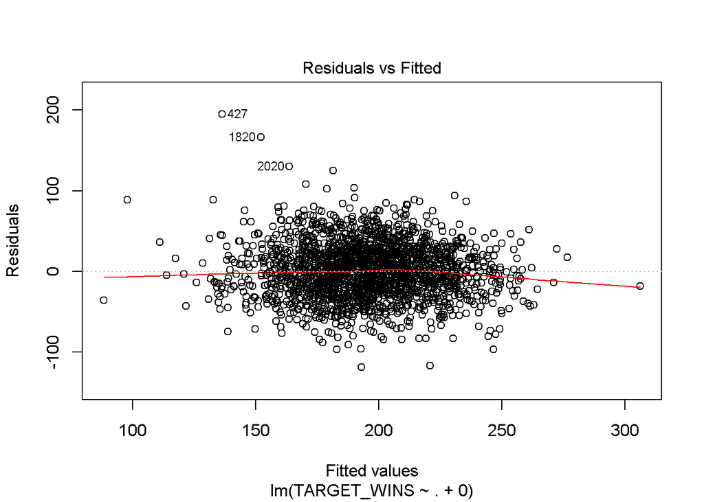

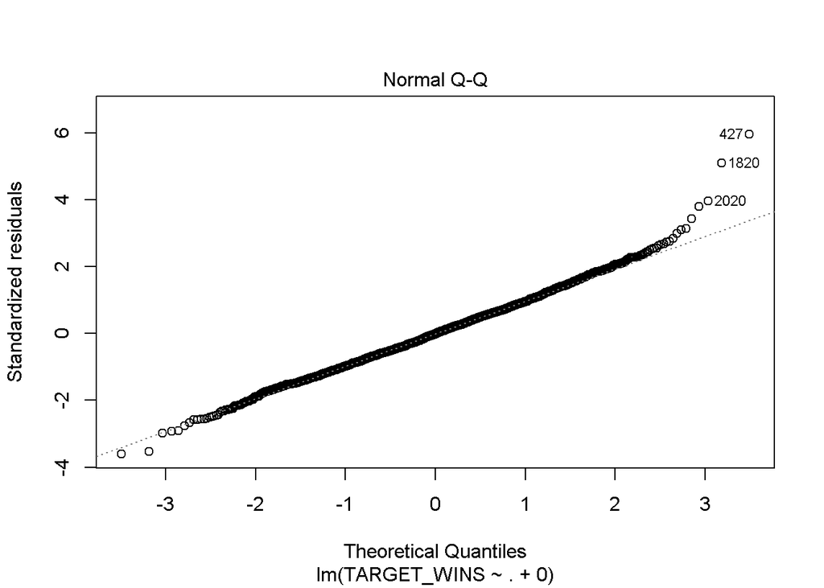

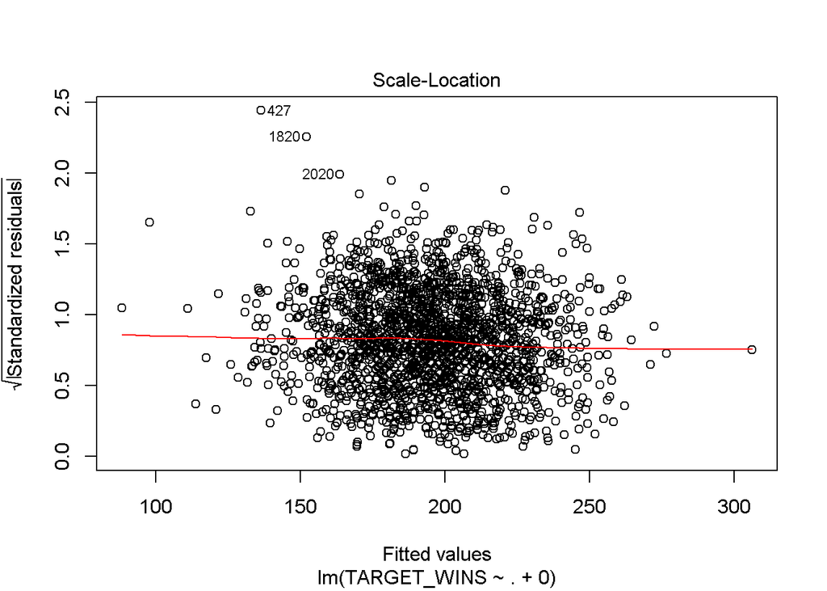

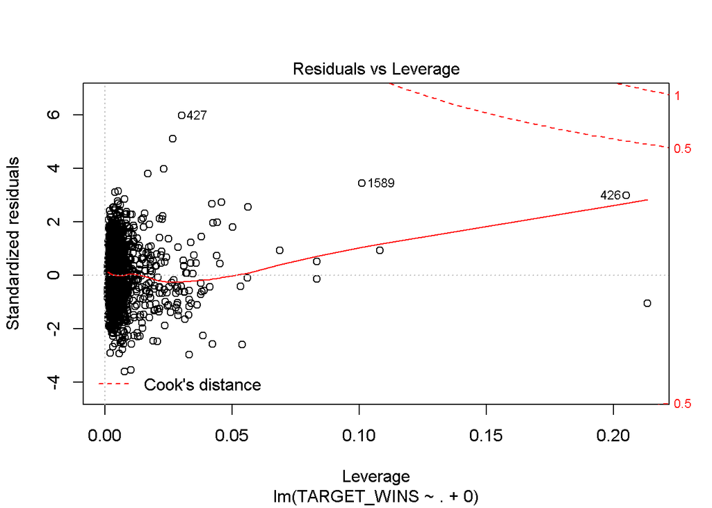

```r
model2 <- model
model2_y_power <- y_power
model2_powers <- y_power

plot(model)
```

# Model 3: A Power Model on Y and X

The residual curves look funky. Let’s apply some power transformations to the same model:

```r
model_data <- valid_data[,c("TEAM_BATTING_H"
,"TEAM_BATTING_3B"
,"TEAM_BATTING_BB"
,"TEAM_FIELDING_E"
,"TEAM_BASERUN_SB"
,"TEAM_FIELDING_DP","TARGET_WINS")]
#,"TEAM_BATTING_HR"
#,"TEAM_PITCHING_HR"
#,"TEAM_PITCHING_BB"

source_cols <- colnames(model_data)

source_cols <- source_cols[source_cols!="TARGET_WINS"]

powers <- lapply(source_cols,function(x){getBoxCoxCoef(model_data[,x],model_data$TARGET_WINS^y_power)})

params <- c(unlist(powers),y_power)
kable(data.frame(variable=c(source_cols,"TARGET_WINS"),power=params))
```

| variable | power |
| --- | --- |
| TEAM_BATTING_H | -0.7 |
| TEAM_BATTING_3B | 1.0 |
| TEAM_BATTING_BB | 1.0 |
| TEAM_FIELDING_E | -1.0 |
| TEAM_BASERUN_SB | 1.0 |
| TEAM_FIELDING_DP | 1.7 |
| TARGET_WINS | 1.2 |

```r
power_transforms <- data.frame(t(apply(model_data,1,function(c) { c^params})))

#model <- lm(TARGET_WINS~.,data=power_transforms[,colnames(power_transforms)[!colnames(power_transforms) %in% c("TEAM_PITCHING_H","TEAM_BATTING_H")]])
#summary(model)
model <- lm(TARGET_WINS~.+0,power_transforms)
summary(model)
```

```
##
## Call:
## lm(formula = TARGET_WINS ~ . + 0, data = power_transforms)
##
## Residuals:
##      Min       1Q   Median       3Q      Max
## -129.735  -23.563   -0.472   23.635  173.959
##
## Coefficients:
##                    Estimate Std. Error t value Pr(>|t|)
## TEAM_BATTING_H    2.659e+03  9.093e+02   2.925  0.00349 **
## TEAM_BATTING_3B   9.074e-01  4.267e-02  21.265  < 2e-16 ***
## TEAM_BATTING_BB   1.417e-01  9.579e-03  14.791  < 2e-16 ***
## TEAM_FIELDING_E   9.786e+03  4.942e+02  19.804  < 2e-16 ***
## TEAM_BASERUN_SB   7.348e-02  1.182e-02   6.215 6.20e-10 ***
## TEAM_FIELDING_DP -2.769e-03  6.525e-04  -4.244 2.29e-05 ***
## ---
## Signif. codes:  0 '***' 0.001 '**' 0.01 '*' 0.05 '.' 0.1 ' ' 1
##
## Residual standard error: 36.45 on 2076 degrees of freedom
## Multiple R-squared:  0.9668, Adjusted R-squared:  0.9667
## F-statistic: 1.007e+04 on 6 and 2076 DF,  p-value: < 2.2e-16
```

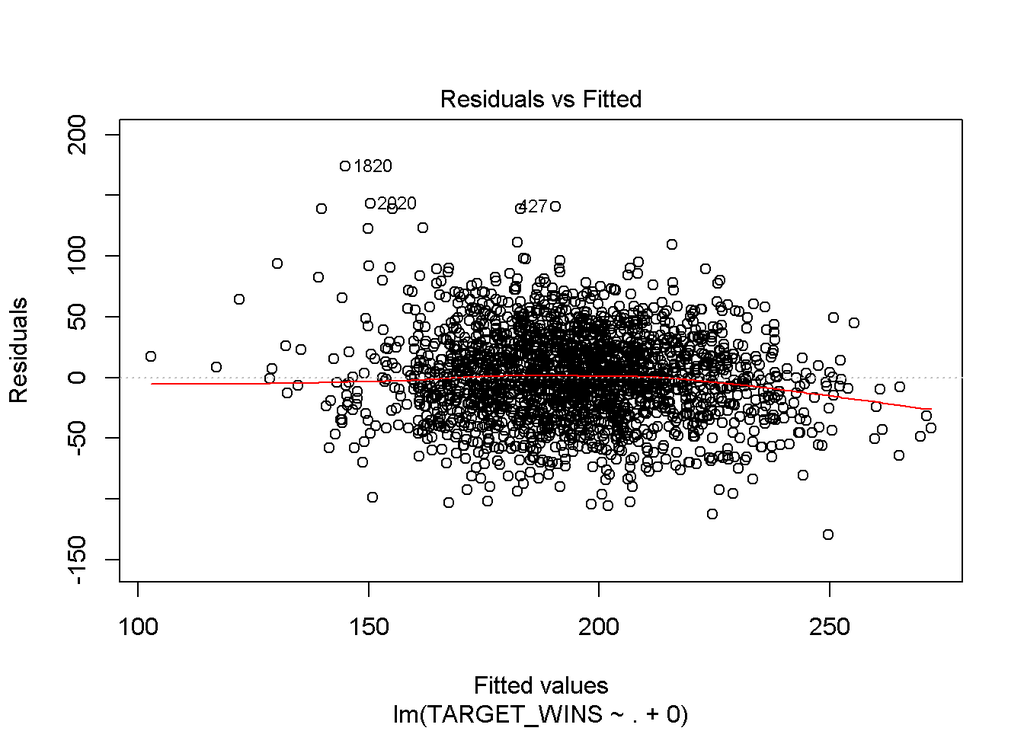

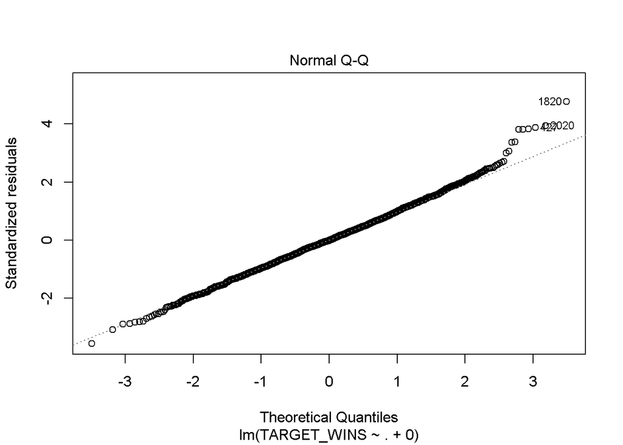

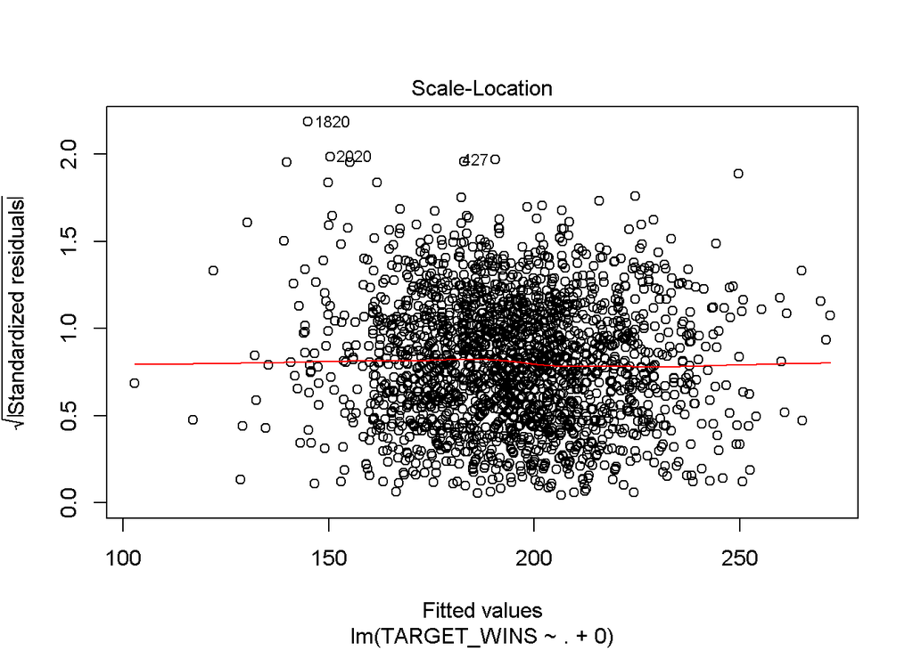

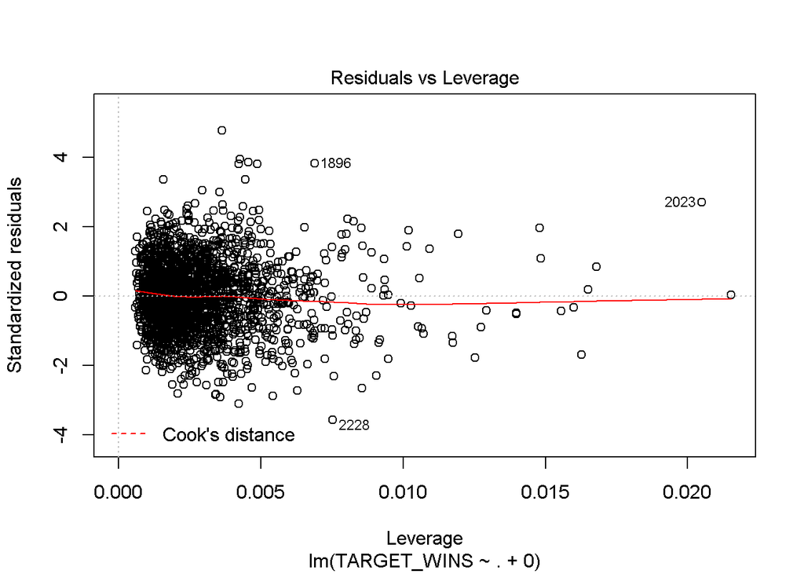

```r
model3 <- model
model3_y_power <- y_power
model3_powers <- powers
plot(model)
```

# Models With Advanced Feature/Transformation Selection: Evaluating transformations

Let’s get fancy by trying other variables/combinations

```r
combinations <- t(combn(colnames(valid_data)[colnames(valid_data)!="TARGET_WINS"],2))

try_Variable <- function(x,y,label){
  y_power <- getBoxCoxCoef(y+0.00001,x)
  x_power <- getBoxCoxCoef(x+0.00001,y)
  model <- lm(I(y^y_power)~I(x^x_power)+0)
  s <- summary(model)
  res <- data.frame(try=paste0(label,"^",x_power),
                    r2=s$r.squared,
                    x_power=x_power,
                    y_power=y_power,
             coef=s$coefficients[,"Estimate"][1],
             coef_p=s$coefficients[,"Pr(>|t|)"][1],
             t_value=s$coefficients[,"t value"][1],
             min_x=min(x),
             max_x=max(x),
             f=s$fstatistic["value"],
             mse=mean(s$residuals^2),
             rse=sd(s$residuals),
             stringsAsFactors=FALSE
  )
  rownames(res) <- NULL
  res
}

evaluate_variables <- function(data,combination,target){
  try_this <- data.frame(x = data[,combination[1]]*data[,combination[2]],y=data[,target])
  res_1 <- try_Variable(try_this$x,try_this$y,paste0("(",combination[1],"*",combination[2],")"))

  try_this <- data.frame(x = data[,combination[1]]/(data[,combination[2]]+0.0000001),y=data[,target])
  res_2 <- try_Variable(try_this$x,try_this$y,paste0("(",combination[1],"/",combination[2],")"))

  total<-rbind(res_1,res_2)
  rownames(total) <- NULL
  total
}

evaluate_variable <- function(data,variable,target){
  try_this <- data.frame(x = data[,variable],y=data[,target])
  res_1 <- try_Variable(try_this$x,try_this$y,paste0("(",variable,")"))


  rownames(res_1) <- NULL
  res_1
}

evaluate_variable_log <- function(data,variable,target){
  try_this <- data.frame(x = log(data[,variable]+0.000001),y=data[,target])
  res_1 <- try_Variable(try_this$x,try_this$y,paste0("log(",variable,")"))


  rownames(res_1) <- NULL
  res_1
}

unique_cols <- c(unique(c(combinations[,1],combinations[,2])))


the_medium_tamale<-lapply(unique_cols,function(c){evaluate_variable(valid_data,c,"TARGET_WINS")})
the_medium_tamale<-do.call(rbind,the_medium_tamale)

the_log_tamale<-lapply(unique_cols,function(c){evaluate_variable_log(valid_data,c,"TARGET_WINS")})
the_log_tamale<-do.call(rbind,the_log_tamale)

the_big_tamale<-apply(combinations,1,function(c){evaluate_variables(valid_data,c,"TARGET_WINS")})
the_big_tamale<-do.call(rbind,the_big_tamale)

the_tamale <- rbind(the_medium_tamale,the_log_tamale,the_big_tamale)

kable(the_tamale[order(-the_tamale$r2),])
```

|  | try | r2 | x_power | y_power | coef | coef_p | t_value | min_x | max_x | f | mse | rse |
| --- | --- | --- | --- | --- | --- | --- | --- | --- | --- | --- | --- | --- |
| 21 | log(TEAM_PITCHING_BB)^1.9 | 0.9549735 | 1.9 | 1.3 | 9.223931e+00 | 0 | 210.08622 | 5.743003e+00 | 6.726233e+00 | 44136.2208 | 4373.330 | 66.14700 |
| 18 | log(TEAM_BATTING_BB)^2 | 0.9548636 | 2.0 | 1.3 | 7.805347e+00 | 0 | 209.81825 | 5.641907e+00 | 6.672033e+00 | 44023.6972 | 4384.004 | 66.22772 |
| 33 | (TEAM_BATTING_H*TEAM_BATTING_BB)^0.7 | 0.9547029 | 0.7 | 1.3 | 2.317080e-02 | 0 | 209.42808 | 3.388770e+05 | 1.336995e+06 | 43860.1189 | 4399.613 | 66.29999 |
| 27 | (TEAM_BATTING_H*TEAM_BATTING_2B)^0.4 | 0.9544827 | 0.4 | 1.3 | 1.837889e+00 | 0 | 208.89672 | 1.346380e+05 | 6.809880e+05 | 43637.8393 | 4421.004 | 66.49837 |
| 61 | (TEAM_BATTING_2B*TEAM_PITCHING_BB)^0.4 | 0.9542975 | 0.4 | 1.3 | 2.719403e+00 | 0 | 208.45286 | 3.936000e+04 | 2.776100e+05 | 43452.5948 | 4438.990 | 66.62385 |
| 15 | log(TEAM_BATTING_2B)^2 | 0.9538742 | 2.0 | 1.3 | 1.013745e+01 | 0 | 207.44819 | 4.770685e+00 | 5.921578e+00 | 43034.7526 | 4480.102 | 66.94838 |
| 2 | (TEAM_BATTING_2B)^0.6 | 0.9503714 | 0.6 | 1.3 | 1.126700e+01 | 0 | 199.62586 | 1.180000e+02 | 3.730000e+02 | 39850.4841 | 4820.320 | 69.41189 |
| 14 | log(TEAM_BATTING_H)^-2 | 0.9481607 | -2.0 | 1.3 | 1.607834e+04 | 0 | 195.09552 | 7.036149e+00 | 7.618251e+00 | 38062.2612 | 5035.046 | 70.97196 |
| 26 | log(TEAM_FIELDING_DP)^2 | 0.9461268 | 2.0 | 1.3 | 1.217963e+01 | 0 | 191.17211 | 4.219508e+00 | 5.416100e+00 | 36546.7752 | 5232.586 | 72.33528 |
| 55 | (TEAM_BATTING_2B*TEAM_BATTING_BB)^0.6 | 0.9455240 | 0.6 | 1.3 | 2.615050e-01 | 0 | 190.05080 | 3.504600e+04 | 2.466240e+05 | 36119.3064 | 5291.140 | 72.55705 |
| 5 | (TEAM_BATTING_BB)^1 | 0.9436301 | 1.0 | 1.3 | 5.739900e-01 | 0 | 186.64364 | 2.820000e+02 | 7.900000e+02 | 34835.8478 | 5475.093 | 73.80265 |
| 28 | (TEAM_BATTING_H/TEAM_BATTING_2B)^-0.8 | 0.9427479 | -0.8 | 1.3 | 1.270060e+03 | 0 | 185.11351 | 4.253125e+00 | 1.059350e+01 | 34267.0105 | 5560.776 | 74.49935 |
| 8 | (TEAM_PITCHING_BB)^1 | 0.9424247 | 1.0 | 1.3 | 5.428864e-01 | 0 | 184.56165 | 3.120000e+02 | 8.340000e+02 | 34063.0010 | 5592.163 | 74.56111 |
| 22 | log(TEAM_FIELDING_E)^-2 | 0.9421453 | -2.0 | 1.2 | 4.975845e+03 | 0 | 184.08813 | 4.174387e+00 | 6.872128e+00 | 33888.4397 | 2307.454 | 47.86170 |
| 1 | (TEAM_BATTING_H)^-0.7 | 0.9406519 | -0.7 | 1.3 | 4.926394e+04 | 0 | 181.61305 | 1.137000e+03 | 2.035000e+03 | 32983.3004 | 5764.357 | 75.90784 |
| 16 | log(TEAM_BATTING_3B)^0.8 | 0.9406243 | 0.8 | 1.4 | 1.596827e+02 | 0 | 181.56814 | 2.397895e+00 | 4.990433e+00 | 32966.9876 | 14058.369 | 118.54831 |
| 19 | log(TEAM_PITCHING_H)^-2 | 0.9405439 | -2.0 | 1.4 | 2.535857e+04 | 0 | 181.43769 | 7.036149e+00 | 7.972811e+00 | 32919.6370 | 14077.388 | 118.66866 |
| 111 | (TEAM_BATTING_BB*TEAM_PITCHING_H)^1 | 0.9372627 | 1.0 | 1.4 | 5.746000e-04 | 0 | 176.32093 | 3.629340e+05 | 1.641186e+06 | 31089.0696 | 14854.282 | 121.32978 |
| 39 | (TEAM_BATTING_H*TEAM_PITCHING_BB)^1 | 0.9372625 | 1.0 | 1.4 | 5.746000e-04 | 0 | 176.32063 | 3.625440e+05 | 1.640210e+06 | 31088.9643 | 14854.329 | 121.32993 |
| 24 | log(TEAM_BASERUN_SB)^0.9 | 0.9368255 | 0.9 | 1.4 | 1.182747e+02 | 0 | 175.66878 | 2.890372e+00 | 6.448889e+00 | 30859.5186 | 14957.796 | 122.20623 |
| 25 | log(TEAM_PITCHING_SO)^2 | 0.9362389 | 2.0 | 1.4 | 1.059959e+01 | 0 | 174.80399 | 5.831882e+00 | 7.307202e+00 | 30556.4365 | 15096.699 | 122.83648 |
| 43 | (TEAM_BATTING_H*TEAM_BATTING_SO)^0.5 | 0.9358626 | 0.5 | 1.3 | 2.871700e-01 | 0 | 174.25544 | 4.859730e+05 | 1.927822e+06 | 30364.9591 | 6229.533 | 78.75367 |
| 182 | (TEAM_PITCHING_SO/TEAM_FIELDING_DP)^0.4 | 0.9349638 | 0.4 | 1.3 | 1.521065e+02 | 0 | 172.96410 | 1.811594e+00 | 1.300000e+01 | 29916.5797 | 6316.827 | 79.32624 |
| 98 | (TEAM_BATTING_HR/TEAM_PITCHING_HR)^2 | 0.9349085 | 2.0 | 1.3 | 3.291615e+02 | 0 | 172.88539 | 5.121951e-01 | 1.014815e+00 | 29889.3596 | 6322.205 | 79.34657 |
| 36 | (TEAM_BATTING_H/TEAM_PITCHING_H)^2 | 0.9347578 | 2.0 | 1.3 | 3.291342e+02 | 0 | 172.67170 | 5.184419e-01 | 1.018544e+00 | 29815.5166 | 6336.841 | 79.43780 |
| 116 | (TEAM_BATTING_BB/TEAM_PITCHING_BB)^2 | 0.9347576 | 2.0 | 1.3 | 3.291232e+02 | 0 | 172.67152 | 5.183824e-01 | 1.018116e+00 | 29815.4547 | 6336.854 | 79.43791 |
| 23 | log(TEAM_BATTING_SO)^2 | 0.9347420 | 2.0 | 1.4 | 1.075618e+01 | 0 | 172.64936 | 5.730100e+00 | 7.243513e+00 | 29807.8009 | 15451.116 | 124.24704 |
| 174 | (TEAM_BATTING_SO/TEAM_PITCHING_SO)^2 | 0.9347301 | 2.0 | 1.3 | 3.294563e+02 | 0 | 172.63258 | 5.181932e-01 | 1.018735e+00 | 29802.0080 | 6339.526 | 79.45432 |
| 126 | (TEAM_BATTING_BB/TEAM_FIELDING_DP)^1 | 0.9337496 | 1.0 | 1.3 | 8.198457e+01 | 0 | 171.26042 | 1.883721e+00 | 6.882353e+00 | 29330.1318 | 6434.762 | 79.70940 |
| 139 | (TEAM_PITCHING_H*TEAM_FIELDING_DP)^0.7 | 0.9314228 | 0.7 | 1.4 | 8.279110e-02 | 0 | 168.12007 | 8.798400e+04 | 4.265220e+05 | 28264.3595 | 16236.998 | 127.16550 |

[output cut: 152 more lines]

### Models Based on Calculated Measures - Model 4

```r
########
# select columns for model

head(the_tamale[order(-the_tamale$r2),c("try","r2","coef_p")],5)
```

```
##                                       try        r2 coef_p
## 21              log(TEAM_PITCHING_BB)^1.9 0.9549735      0
## 18                 log(TEAM_BATTING_BB)^2 0.9548636      0
## 33   (TEAM_BATTING_H*TEAM_BATTING_BB)^0.7 0.9547029      0
## 27   (TEAM_BATTING_H*TEAM_BATTING_2B)^0.4 0.9544827      0
## 61 (TEAM_BATTING_2B*TEAM_PITCHING_BB)^0.4 0.9542975      0
```

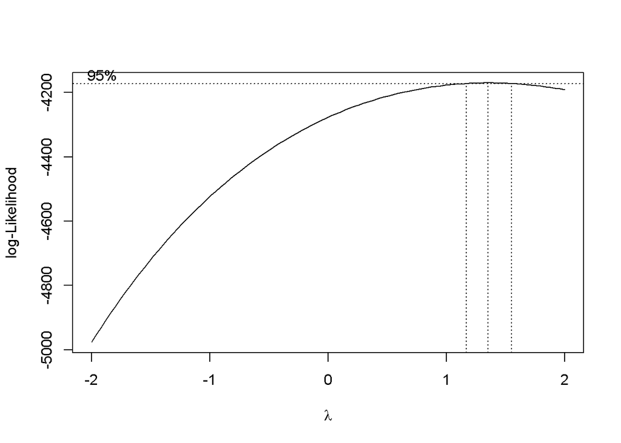

```r
model_data <- data.frame(LOG_TEAM_PITCHING_BB = with(valid_data,log(TEAM_PITCHING_BB)),
LOG_TEAM_BATTING_BB = with(valid_data,log(TEAM_BATTING_BB)),
TEAM_BATTING_H_BY_TEAM_BATTING_BB = with(valid_data,(TEAM_BATTING_H*TEAM_BATTING_BB)),
TEAM_BATTING_H_BY_TEAM_BATTING_2B = with(valid_data,(TEAM_BATTING_H*TEAM_BATTING_2B)),
TEAM_BATTING_2B_BY_TEAM_PITCHING_BB = with(valid_data,(TEAM_BATTING_2B*TEAM_PITCHING_BB)),
  TARGET_WINS=with(valid_data,TARGET_WINS)
)

d<-boxcox(TARGET_WINS+0.0001~.,data=model_data, plotit = TRUE)
```

```r
d <- data.frame(d)

y_power <- d[d$y == max(d$y),]$x

source_cols <- colnames(model_data)

source_cols <- source_cols[source_cols!="TARGET_WINS"]

powers <- lapply(source_cols,function(x){getBoxCoxCoef(model_data[,x],model_data$TARGET_WINS^y_power)})

params <- c(unlist(powers),y_power)
kable(data.frame(variable=c(source_cols,"TARGET_WINS"),power=params))
```

| variable | power |
| --- | --- |
| LOG_TEAM_PITCHING_BB | 1.900000 |
| LOG_TEAM_BATTING_BB | 2.000000 |
| TEAM_BATTING_H_BY_TEAM_BATTING_BB | 0.700000 |
| TEAM_BATTING_H_BY_TEAM_BATTING_2B | 0.400000 |
| TEAM_BATTING_2B_BY_TEAM_PITCHING_BB | 0.400000 |
| TARGET_WINS | 1.353535 |

```r
power_transforms <- data.frame(t(apply(model_data,1,function(c) { c^params})))


#model <- lm(TARGET_WINS~.,data=power_transforms[,colnames(power_transforms)[!colnames(power_transforms) %in% c("TEAM_PITCHING_H","TEAM_BATTING_H")]])
#summary(model)
model <- lm(TARGET_WINS~.+0,power_transforms[,colnames(power_transforms)[!colnames(power_transforms) %in% c("TEAM_BATTING_3B_BY_TEAM_PITCHING_HR","TEAM_BATTING_BB_BY_TEAM_PITCHING_BB")]])
summary(model)
```

```
##
## Call:
## lm(formula = TARGET_WINS ~ . + 0, data = power_transforms[, colnames(power_transforms)[!colnames(power_transforms) %in%
##     c("TEAM_BATTING_3B_BY_TEAM_PITCHING_HR", "TEAM_BATTING_BB_BY_TEAM_PITCHING_BB")]])
##
## Residuals:
##      Min       1Q   Median       3Q      Max
## -277.599  -56.184   -0.364   55.354  314.072
##
## Coefficients:
##                                       Estimate Std. Error t value Pr(>|t|)
## LOG_TEAM_PITCHING_BB                 16.635307   2.417770   6.880 7.87e-12
## LOG_TEAM_BATTING_BB                 -11.954161   2.143930  -5.576 2.78e-08
## TEAM_BATTING_H_BY_TEAM_BATTING_BB     0.030138   0.002491  12.097  < 2e-16
## TEAM_BATTING_H_BY_TEAM_BATTING_2B     2.112645   0.184609  11.444  < 2e-16
## TEAM_BATTING_2B_BY_TEAM_PITCHING_BB  -3.939456   0.454639  -8.665  < 2e-16
##
## LOG_TEAM_PITCHING_BB                ***
## LOG_TEAM_BATTING_BB                 ***
## TEAM_BATTING_H_BY_TEAM_BATTING_BB   ***
## TEAM_BATTING_H_BY_TEAM_BATTING_2B   ***
## TEAM_BATTING_2B_BY_TEAM_PITCHING_BB ***
## ---
## Signif. codes:  0 '***' 0.001 '**' 0.01 '*' 0.05 '.' 0.1 ' ' 1
##
## Residual standard error: 82.3 on 2077 degrees of freedom
## Multiple R-squared:  0.9568, Adjusted R-squared:  0.9567
## F-statistic:  9204 on 5 and 2077 DF,  p-value: < 2.2e-16
```

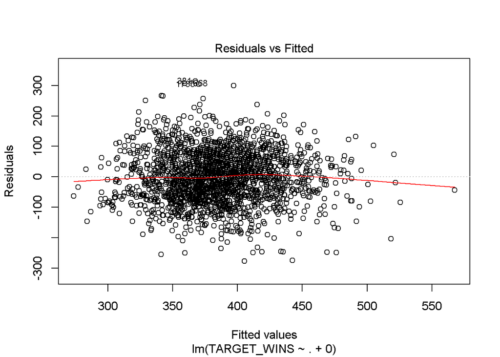

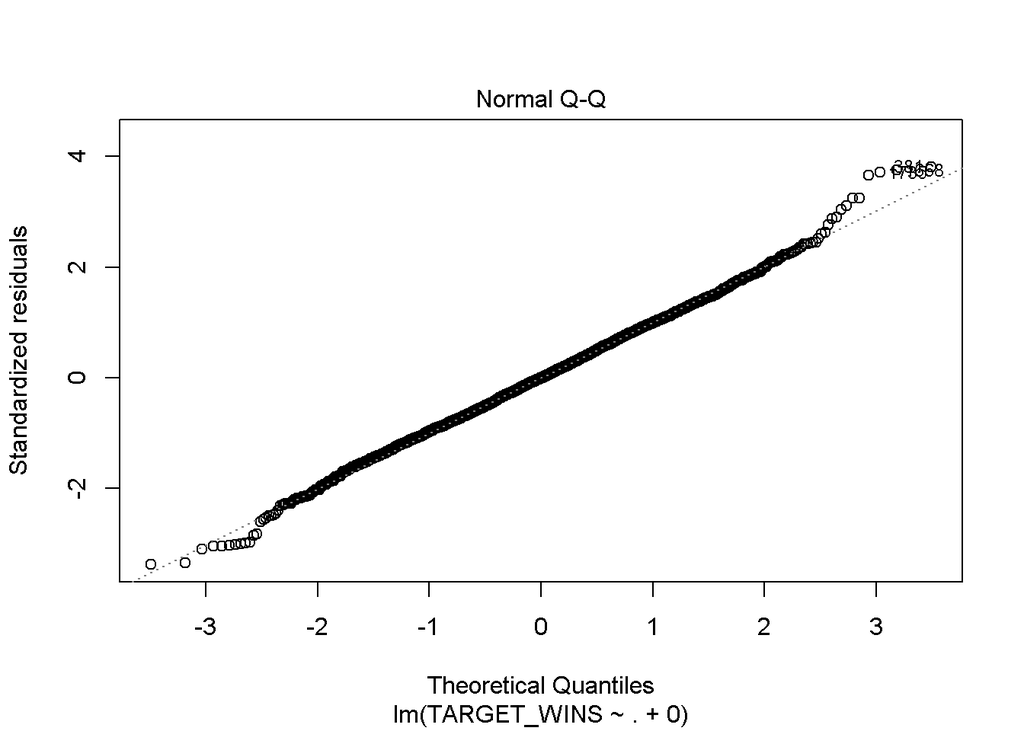

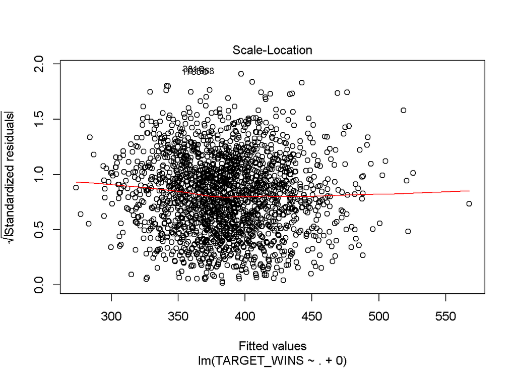

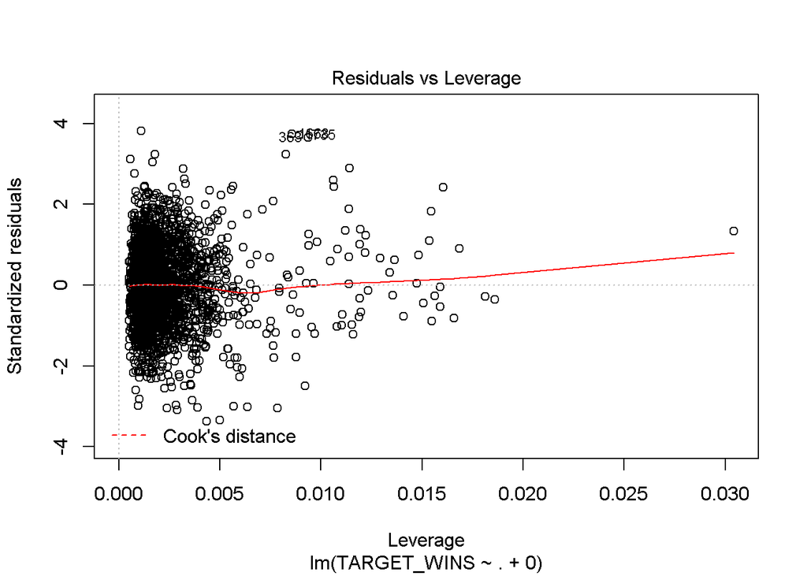

```r
model4 <- model
model4_y_power <- y_power
model4_powers <- powers

plot(model)
```

# Model 5: A Straight Up Model, w/o intercept calcellation

Let’s try a straight up regression whatever linear regression

```r
model <- lm(TARGET_WINS~.,data=valid_data)
summary(model)
```

```
##
## Call:
## lm(formula = TARGET_WINS ~ ., data = valid_data)
##
## Residuals:
##     Min      1Q  Median      3Q     Max
## -43.316  -7.494   0.150   7.530  66.987
##
## Coefficients:
##                   Estimate Std. Error t value Pr(>|t|)
## (Intercept)      39.906223   5.842738   6.830 1.11e-11 ***
## TEAM_BATTING_H   -0.068565   0.011620  -5.901 4.22e-09 ***
## TEAM_BATTING_2B  -0.037171   0.009140  -4.067 4.95e-05 ***
## TEAM_BATTING_3B   0.172414   0.018602   9.268  < 2e-16 ***
## TEAM_BATTING_HR   0.475803   0.075484   6.303 3.55e-10 ***
## TEAM_BATTING_BB   0.379235   0.034381  11.030  < 2e-16 ***
## TEAM_PITCHING_H   0.093178   0.009827   9.482  < 2e-16 ***
## TEAM_PITCHING_HR -0.370954   0.071460  -5.191 2.30e-07 ***
## TEAM_PITCHING_BB -0.326856   0.032029 -10.205  < 2e-16 ***
## TEAM_FIELDING_E  -0.068667   0.004248 -16.164  < 2e-16 ***
## TEAM_BATTING_SO  -0.114314   0.016705  -6.843 1.02e-11 ***
## TEAM_BASERUN_SB   0.062922   0.004691  13.414  < 2e-16 ***
## TEAM_PITCHING_SO  0.096919   0.015632   6.200 6.80e-10 ***
## TEAM_FIELDING_DP -0.101177   0.012194  -8.298  < 2e-16 ***
## ---
## Signif. codes:  0 '***' 0.001 '**' 0.01 '*' 0.05 '.' 0.1 ' ' 1
##
## Residual standard error: 11.47 on 2068 degrees of freedom
## Multiple R-squared:  0.3505, Adjusted R-squared:  0.3464
## F-statistic: 85.85 on 13 and 2068 DF,  p-value: < 2.2e-16
```

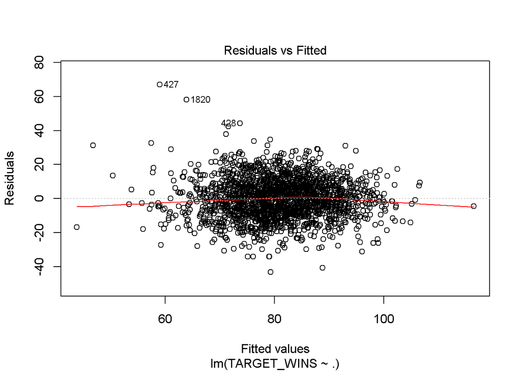

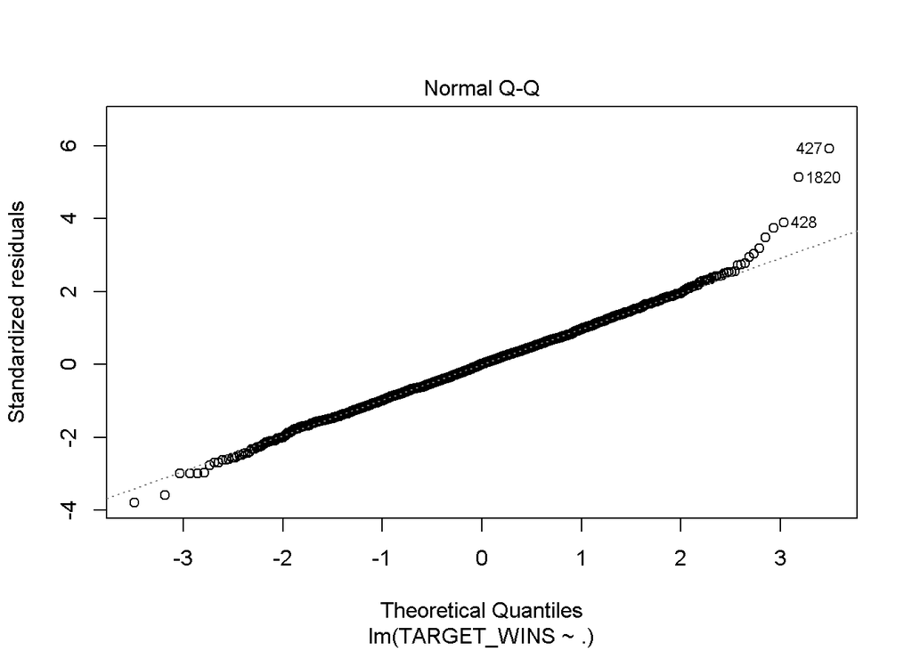

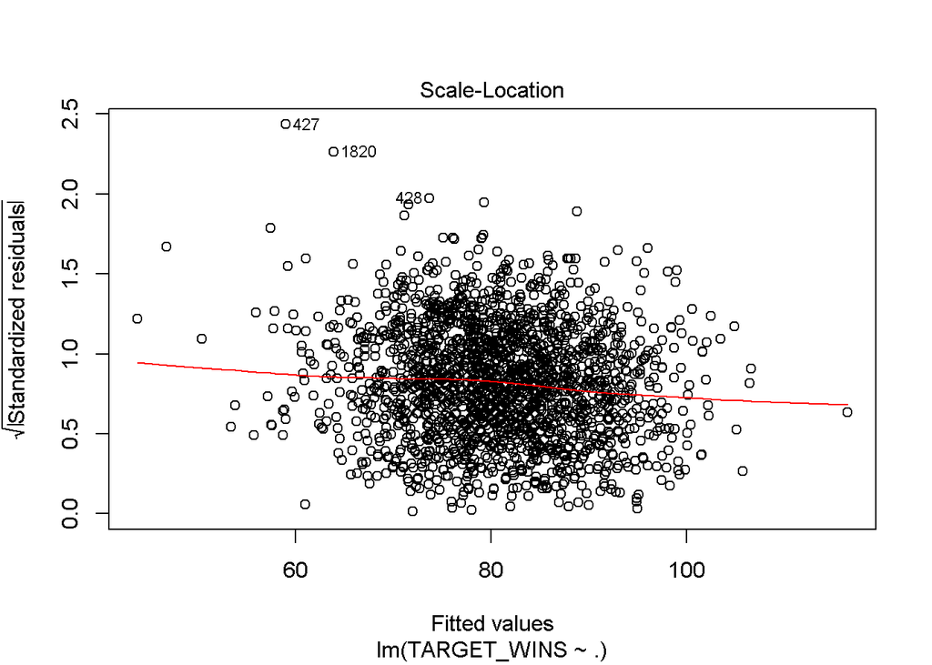

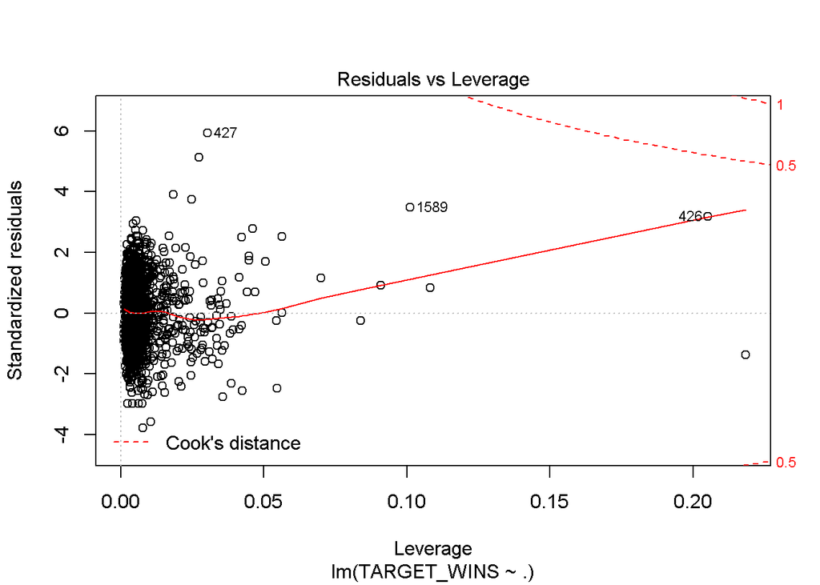

```r
model5 <- model
model5_y_power <- 1
model5_powers <- powers

plot(model)
```

## 3. BUILD MODELS (25 Points)

We built/evaluated the following models:

Using the training data set, build at least three different multiple linear regression models, using different variables (or the same variables with different transformations). Since we have not yet covered automated variable selection methods, you should select the variables manually (unless you previously learned Forward or Stepwise selection, etc.). Since you manually selected a variable for inclusion into the model or exclusion into the model, indicate why this was done.

Discuss the coefficients in the models, do they make sense? For example, if a team hits a lot of Home Runs, it would be reasonably expected that such a team would win more games. However, if the coefficient is negative (suggesting that the team would lose more games), then that needs to be discussed. Are you keeping the model even though it is counter intuitive? Why? The boss needs to know.

## 4. SELECT MODELS (25 Points)

Decide on the criteria for selecting the best multiple linear regression model. Will you select a model with slightly worse performance if it makes more sense or is more parsimonious? Discuss why you selected your model. For the multiple linear regression model, will you use a metric such as Adjusted R2, RMSE, etc.? Be sure to explain how you can make inferences from the model, discuss multi-collinearity issues (if any), and discuss other relevant model output. Using the training data set, evaluate the multiple linear regression model based on

1. mean squared error
2. R2,
3. F-statistic,
4. residual plots.

Make predictions using the training_transformed data set.

```r
models <- list(model0,model1,model2,model3,model4,model5)

model_metrics <- lapply(models,function (m){
  s <- summary(m)
  res <- data.frame(r2=s$r.squared,
          rse=s$sigma,
          me=sqrt(mean(s$residuals^2)),
          fstatistic=head(c(s$fstatistic[1],1),1),
          fstatistic_df1=head(c(s$fstatistic[2],1),1),
          fstatistic_df2=head(c(s$fstatistic[3],nrow(valid_data)),1)
          )
  res
  })

combined_results <- do.call(rbind,model_metrics)
rownames(combined_results) <- NULL
combined_results <- data.frame(
  model = c("model1","model3","model3-1","model3-2","model4","model2"),
  description = c("Mean-based model","Model with Straight-Up Variables, Zero Intercept","Model with Y Power Transformation Using Boxcox","Model with X&Y  Power Transformation Using Boxcox", "Model with Y & Automatic Feature Set 1 w/Power Transformation Using Boxcox", "Model with Straight-Up Variables"),
  combined_results)

y_powers<- c(model0_y_power,model1_y_power,model2_y_power,model3_y_power,model4_y_power,model5_y_power)
combined_results$me <- combined_results$me ^ (1/y_powers)
kable(combined_results)
```

| model | description | r2 | rse | me | fstatistic | fstatistic_df1 | fstatistic_df2 |
| --- | --- | --- | --- | --- | --- | --- | --- |
| model1 | Mean-based model | 0.0000000 | 14.18806 | 14.18465 | 1.0000 | 1 | 2082 |
| model3 | Model with Straight-Up Variables, Zero Intercept | 0.9801910 | 11.59599 | 11.55973 | 7875.2786 | 13 | 2069 |
| model3-1 | Model with Y Power Transformation Using Boxcox | 0.9726027 | 33.15973 | 18.45196 | 5649.9620 | 13 | 2069 |
| model3-2 | Model with X&Y Power Transformation Using Boxcox | 0.9667822 | 36.45101 | 19.99413 | 10070.0951 | 6 | 2076 |
| model4 | Model with Y & Automatic Feature Set 1 w/Power Transformation Using Boxcox | 0.9568147 | 82.30408 | 25.98597 | 9203.6234 | 5 | 2077 |
| model2 | Model with Straight-Up Variables | 0.3505140 | 11.47014 | 11.43151 | 85.8505 | 13 | 2068 |

```r
combined_results <-combined_results[order(combined_results$model),]
kable(combined_results[combined_results$model %in% c("model1","model2","model3","model4"),])
```

|  | model | description | r2 | rse | me | fstatistic | fstatistic_df1 | fstatistic_df2 |
| --- | --- | --- | --- | --- | --- | --- | --- | --- |
| 1 | model1 | Mean-based model | 0.0000000 | 14.18806 | 14.18465 | 1.0000 | 1 | 2082 |
| 6 | model2 | Model with Straight-Up Variables | 0.3505140 | 11.47014 | 11.43151 | 85.8505 | 13 | 2068 |
| 2 | model3 | Model with Straight-Up Variables, Zero Intercept | 0.9801910 | 11.59599 | 11.55973 | 7875.2786 | 13 | 2069 |
| 5 | model4 | Model with Y & Automatic Feature Set 1 w/Power Transformation Using Boxcox | 0.9568147 | 82.30408 | 25.98597 | 9203.6234 | 5 | 2077 |

# Predictions

```r
# make up for missing values in the evaluation dataset by imputing wiht the training medians

# make up for missing TEAM_BATTING_SO
evaluation[is.na(evaluation$TEAM_BATTING_SO),]$TEAM_BATTING_SO <- median(training$TEAM_BATTING_SO, na.rm = TRUE)

# make up for missing TEAM_BASERUN_SB
evaluation[is.na(evaluation$TEAM_BASERUN_SB),]$TEAM_BASERUN_SB <- median(training$TEAM_BASERUN_SB, na.rm = TRUE)

# make up for missing TEAM_PITCHING_SO
evaluation[is.na(evaluation$TEAM_PITCHING_SO),]$TEAM_PITCHING_SO <- median(training$TEAM_PITCHING_SO, na.rm = TRUE)

# make up for missing TEAM_FIELDING_DP
evaluation[is.na(evaluation$TEAM_FIELDING_DP),]$TEAM_FIELDING_DP <- median(training$TEAM_FIELDING_DP, na.rm = TRUE)


# apply validation rules

evaluation$INVALID <- FALSE
evaluation$INVALID <- evaluation$INVALID | evaluation$TEAM_BATTING_2B < 110 | evaluation$TEAM_BATTING_2B>376
length(evaluation$INVALID[evaluation$INVALID])
```

```
## [1] 2
```

```r
evaluation$INVALID <- evaluation$INVALID | evaluation$TEAM_BATTING_3B < 11 | evaluation$TEAM_BATTING_3B>153
length(evaluation$INVALID[evaluation$INVALID])
```

```
## [1] 3
```

```r
evaluation$INVALID <- evaluation$INVALID | evaluation$TEAM_BATTING_HR < 3 | evaluation$TEAM_BATTING_HR>264
length(evaluation$INVALID[evaluation$INVALID])
```

```
## [1] 3
```

```r
evaluation$INVALID <- evaluation$INVALID | evaluation$TEAM_BATTING_H < 935 | evaluation$TEAM_BATTING_H>2131
length(evaluation$INVALID[evaluation$INVALID])
```

```
## [1] 4
```

```r
evaluation$INVALID <- evaluation$INVALID | evaluation$TEAM_BATTING_SO < 308 | evaluation$TEAM_BATTING_SO>1535
length(evaluation$INVALID[evaluation$INVALID])
```

```
## [1] 10
```

```r
evaluation$INVALID <- evaluation$INVALID | evaluation$TEAM_PITCHING_SO < 308 | evaluation$TEAM_PITCHING_SO>1535
length(evaluation$INVALID[evaluation$INVALID])
```

```
## [1] 10
```

```r
evaluation$INVALID <- evaluation$INVALID | evaluation$TEAM_BATTING_BB < 282 | evaluation$TEAM_BATTING_BB>835
length(evaluation$INVALID[evaluation$INVALID])
```

```
## [1] 16
```

```r
evaluation$INVALID <- evaluation$INVALID | evaluation$TEAM_PITCHING_BB < 282 | evaluation$TEAM_PITCHING_BB>835
length(evaluation$INVALID[evaluation$INVALID])
```

```
## [1] 20
```

```r
model1_predictions <- predict(model1,evaluation)^(1/model1_y_power)
model1_predictions[evaluation$INVALID] <- NA

model2_predictions <- predict(model2,evaluation)^(1/model2_y_power)
model2_predictions[evaluation$INVALID] <- NA


kable(data.frame(model1_predictions = model1_predictions))
```

## model1_predictions

```
       60.85668
       66.60762
       73.68598
       82.80724
             NA
             NA
       73.77146
       74.94659
       72.15503
       68.94785
       65.95122
       79.61884
       80.62423
       77.27399
       81.45970
       73.89162
       70.67914
       78.44014
       67.00079
       86.68226
       82.60369
       82.87553
       81.45499
       68.21000
       76.20223
       83.07728
             NA
       66.31804
       81.90593
       65.89571
       91.66097
       86.86108
       86.56662
       87.86919
       80.25817
       85.92277
       74.97824
       91.95978
             NA
       88.77946
```

[output cut: 204 more lines]

```
       61.81926
       82.83755
       74.63854
       81.94208
       68.53639
       83.01730
       79.35538
             NA
       86.10966
             NA
       68.22252
       83.71438
       79.40289
       84.17469
       67.71176
```